# HW_13

Cody Grainger

03 August 2020

### Libraries

```r
library(tidyverse)
library(here)
library(ggthemes)
library(gghighlight)
```

#### Part 1: DNA of Strings

Importing “beta_gliadin.txt” with read_lines() and skipping the first line. str_replace_all() is used to remove the white spaces and numbers and the result is assigned to “beta”. A new variable is created to store the collapsed version of “beta”

```r
#Importing the raw data
beta_raw <- read_lines(here("data","beta_gliadin.txt"),skip=1)

#Removing blank spaces
beta <- str_replace_all(beta_raw, "\\s","")

#Removing numbers
(beta <- str_replace_all(beta,"\\d",""))
```

```
 [1] "aatttgacatgcacagctcctgaccctgccaatattgttgcagctgcgctcgcaagcctt"
 [2] "tgcgtagatgatcactttatatgatttgtgtaaaaccaaaataagatctacaaacgaata"
 [3] "gaagctagagcgtaccttggcgtgcacacacattgcaagccatacctaaccttgataagt"
 [4] "gttaatgacttgtacaacatatacatcacttaagacaagtaaaagcgatttgatgagtca"
 [5] "tggtctatcaaagcaagccacattactagtctaatccatcttaacaggtcacgcatgatt"
 [6] "acaatcttgtttgtgtgcaagtcaagcctatctagtttacacgtaacaacttgtaagaac"
 [7] "attaccaaaagttgatgttgctaataagtgtagaacacctacaacactgacatgtaaaag"
 [8] "aatttgatgagtcatggcctactaaagcaagttacattactagtcttatgtatcttaaca"
 [9] "tgccacacaagattacaaactaagttctgtggccagccatgcttatctagtttatgtgta"
[10] "aaaatttgcaaacattacaaacttagtttcagaaaagtaggcaatctagattagtgtttg"
[11] "agttgtaaagtgaacaagatgagtcatgcgtgttatcacacctttttggtggtggaatga"
[12] "tagtgcaacaacaacggaactttcaatgactagtccaagaatacacttgtaagtagtgcc"
[13] "accaaacacaacataccaaattatgattttgggaagcatccaaacactttacacacaagc"
[14] "aaatgccaattgtgaaagagatcatgccatgacagctataaataggcccgcatcgatgat"
[15] "gatcatccttcctcatccatcattctcataagtagagtgcatcattcaaggcaagcaagc"
```

[output cut: 41 more lines]

```r
#using the collapse argument of str_c()
(beta_c <- str_c(beta,collapse=""))
```

```
[1] "aatttgacatgcacagctcctgaccctgccaatattgttgcagctgcgctcgcaagcctt…"
```

Setting the letters to uppercase and finding the string length

```r
#Setting the leters to capital

(beta_c <- str_to_upper(beta_c))
```

```
[1] "AATTTGACATGCACAGCTCCTGACCCTGCCAATATTGTTGCAGCTGCGCTCGCAAGCCTT…"
```

```r
str_length(beta_c)
```

```
[1] 3310
```

Detecting the number of start codon sequences with str_count(). Stop codons TGA and TAA are also displayed.

```r
#Count for ATG
#Start codons
str_count(beta_c,"ATG")
```

```
[1] 66
```

```r
#Count for TGA and TAA
#Stop codons
str_count(beta_c,"TGA|TAA")
```

```
[1] 99
```

Creating variables CAAT_box and TATA_box and searching for them in the sequence

```r
CAAT_box <- "CCAAT"
TATA_box <- "CTATTA"

str_count(beta_c,CAAT_box)
```

```
[1] 4
```

```r
str_count(beta_c,TATA_box)
```

```
[1] 1
```

Creating regex search strings to seach for specific sequences that begin and end with “CCAAT”,“ATG” and “CTATAA”,“ATG”. The found sequences are extracted and printed. Finding seq_length() as well.

```r
"CAAT"
```

```
[1] "CAAT"
```

```r
#CAAT
#Assigning search string
caat_seq <- "CCAAT.{100,150}ATG"
#count for number of times this defined start and stop of sequence shows up
str_count(beta_c,caat_seq)
```

```
[1] 2
```

```r
#Extracting the sequence
(caat_seqs_all <- str_extract_all(beta_c, caat_seq,simplify=TRUE))
```

```
     [,1]
[1,] "CCAATTGTGAAAGAGATCATGCCATGACAGCTATAAATAGGCCCGCATCGATGATGATCATCCTTCCTCATCCATCATTCTCATAAGTAGAGTGCATCATTCAAGGCAAGCAAGCAGTGGTCAATACAAATCCATCATG"
     [,2]
[1,] "CCAATTTCGCAGCAACAAGCACAACAACAACAACAACAACAACAACAACAACAACAACAACAACAACAACAAATCCTTCAACAAATTTTGCAACAACAACTGATTCCATGCAGGGATGTTGTCTTGCAACAACACAACATAGCGCATG"
```

```r
#Length of the extracted sequence
str_length(caat_seqs_all)
```

```
[1] 139 148
```

```r
#Divider
"---------------------"
```

```
[1] "---------------------"
```

```r
"TATA"
```

```
[1] "TATA"
```

```r
#TATA
#Assigning search string
tata_seq <- "CTATAA.{50,100}ATG"
#count for number of times this defined start and stop of sequence shows up
str_count(beta_c,tata_seq)
```

```
[1] 1
```

```r
#Extracting the sequence
(tata_seq_all <- str_extract_all(beta_c, tata_seq,simplify=TRUE))
```

```
     [,1]
[1,] "CTATAAATAGGCCCGCATCGATGATGATCATCCTTCCTCATCCATCATTCTCATAAGTAGAGTGCATCATTCAAGGCAAGCAAGCAGTGGTCAATACAAATCCATCATG"
```

```r
#Length of the extracted sequence
str_length(tata_seq_all)
```

```
[1] 109
```

Using str_which() to find which of the 2 CAAT sequences contains the TATA sequence. Assigning the correct result to a new variable.

```r
#Finding which caat sequence contains tata_seq
str_which(caat_seqs_all,tata_seq)
```

```
[1] 1
```

```r
#Extracting the above sequence into a new variable
(promotor <- str_extract(beta_c,caat_seq))
```

```
[1] "CCAATTGTGAAAGAGATCATGCCATGACAGCTATAAATAGGCCCGCATCGATGATGATCATCCTTCCTCATCCATCATTCTCATAAGTAGAGTGCATCATTCAAGGCAAGCAAGCAGTGGTCAATACAAATCCATCATG"
```

```r
str_length(promotor)
```

```
[1] 139
```

#### Part 2: Ants

importing the ants.csv data

```r
(ants_raw <- read_csv(here("data","ants.csv")))
```

| year | season | seas.code | trt | plot | sample | Aphaenogaster.treatae | Brachymyrmex.depilis | Camponotus.castaneus | Crematogaster.cerasi | Crematogaster.lineolata | Crematogaster.missuriensis | Dolichoderus.plagiatus | Dorymyrmex.flavus | Forelius.pruinosus | Formica.dolosa | Hypoponera.opacior | Monomorium.minimum | Neivamyrmex.nigrescens | Neivamyrmex.opacithorax | Nylanderia.terricola | Nylanderia.trageri | Pheidole.morrisi | Strumigenys.louisianae | Tapimoma.sessile | Temnothorax.pergandei | Trachymyrmex.septentrionalis |
| --- | --- | --- | --- | --- | --- | --- | --- | --- | --- | --- | --- | --- | --- | --- | --- | --- | --- | --- | --- | --- | --- | --- | --- | --- | --- | --- |
| 2010 | May | 1 | Pre-burned | 6A | 1 | 0 | 1 | 0 | 0 | 2 | 2 | 0 | 0 | 0 | 1 | 0 | 0 | 0 | 0 | 0 | 0 | 0 | 0 | 0 | 0 | 0 |
| 2010 | May | 1 | Pre-burned | 6A | 2 | 0 | 0 | 1 | 0 | 0 | 1 | 0 | 0 | 1 | 1 | 0 | 0 | 0 | 0 | 0 | 0 | 0 | 0 | 0 | 0 | 0 |
| 2010 | May | 1 | Pre-burned | 6A | 3 | 0 | 0 | 0 | 0 | 2 | 0 | 0 | 0 | 1 | 0 | 0 | 0 | 0 | 0 | 0 | 0 | 0 | 0 | 0 | 0 | 2 |
| 2010 | May | 1 | Pre-burned | 6A | 4 | 0 | 0 | 0 | 0 | 2 | 0 | 0 | 0 | 0 | 2 | 0 | 0 | 0 | 0 | 0 | 0 | 0 | 0 | 0 | 0 | 0 |
| 2010 | May | 1 | Pre-burned | 6A | 5 | 0 | 1 | 0 | 0 | 2 | 3 | 0 | 0 | 0 | 0 | 0 | 0 | 0 | 0 | 0 | 0 | 0 | 0 | 0 | 0 | 0 |
| 2010 | May | 1 | Pre-burned | 6A | 6 | 0 | 0 | 0 | 0 | 2 | 3 | 0 | 0 | 1 | 2 | 0 | 0 | 0 | 0 | 0 | 0 | 1 | 0 | 0 | 0 | 0 |
| 2010 | May | 1 | Pre-burned | 6A | 7 | 0 | 0 | 0 | 0 | 1 | 0 | 0 | 0 | 0 | 0 | 0 | 0 | 0 | 0 | 0 | 0 | 0 | 0 | 0 | 0 | 0 |
| 2010 | May | 1 | Pre-burned | 6A | 8 | 0 | 0 | 0 | 0 | 3 | 0 | 0 | 0 | 0 | 0 | 2 | 0 | 0 | 0 | 0 | 0 | 0 | 0 | 0 | 0 | 2 |
| 2010 | May | 1 | Pre-burned | 6A | 9 | 0 | 1 | 0 | 0 | 5 | 1 | 0 | 0 | 0 | 0 | 0 | 0 | 0 | 0 | 0 | 0 | 0 | 0 | 0 | 0 | 1 |
| 2010 | May | 1 | Pre-burned | 6A | 10 | 0 | 0 | 0 | 0 | 0 | 0 | 0 | 0 | 0 | 0 | 0 | 0 | 0 | 0 | 0 | 0 | 0 | 0 | 0 | 0 | 0 |

[output cut: 350 more lines]

Tidying the data using regex instead of hard coding all of the names.

```r
ants <- ants_raw %>%
  pivot_longer(names_to = "species", values_to = "abundance", matches("[A-Z].[a-z]", ignore.case = FALSE))

ants
```

| year | season | seas.code | trt | plot | sample | species | abundance |
| --- | --- | --- | --- | --- | --- | --- | --- |
| 2010 | May | 1 | Pre-burned | 6A | 1 | Aphaenogaster.treatae | 0 |
| 2010 | May | 1 | Pre-burned | 6A | 1 | Brachymyrmex.depilis | 1 |
| 2010 | May | 1 | Pre-burned | 6A | 1 | Camponotus.castaneus | 0 |
| 2010 | May | 1 | Pre-burned | 6A | 1 | Crematogaster.cerasi | 0 |
| 2010 | May | 1 | Pre-burned | 6A | 1 | Crematogaster.lineolata | 2 |
| 2010 | May | 1 | Pre-burned | 6A | 1 | Crematogaster.missuriensis | 2 |
| 2010 | May | 1 | Pre-burned | 6A | 1 | Dolichoderus.plagiatus | 0 |
| 2010 | May | 1 | Pre-burned | 6A | 1 | Dorymyrmex.flavus | 0 |
| 2010 | May | 1 | Pre-burned | 6A | 1 | Forelius.pruinosus | 0 |
| 2010 | May | 1 | Pre-burned | 6A | 1 | Formica.dolosa | 1 |

[output cut: 990 more lines]

```r
ants2 <- ants %>%
  mutate(species = str_replace(species, "[a-z].[a-z]", "[^A-Z]{1)+[a-z]{3}+"))

ants2
```

| year | season | seas.code | trt | plot | sample | species | abundance |
| --- | --- | --- | --- | --- | --- | --- | --- |
| 2010 | May | 1 | Pre-burned | 6A | 1 | A[^A-Z]{1)+[a-z]{3}+enogaster.treatae | 0 |
| 2010 | May | 1 | Pre-burned | 6A | 1 | B[^A-Z]{1)+[a-z]{3}+hymyrmex.depilis | 1 |
| 2010 | May | 1 | Pre-burned | 6A | 1 | C[^A-Z]{1)+[a-z]{3}+onotus.castaneus | 0 |
| 2010 | May | 1 | Pre-burned | 6A | 1 | C[^A-Z]{1)+[a-z]{3}+atogaster.cerasi | 0 |
| 2010 | May | 1 | Pre-burned | 6A | 1 | C[^A-Z]{1)+[a-z]{3}+atogaster.lineolata | 2 |
| 2010 | May | 1 | Pre-burned | 6A | 1 | C[^A-Z]{1)+[a-z]{3}+atogaster.missuriensis | 2 |
| 2010 | May | 1 | Pre-burned | 6A | 1 | D[^A-Z]{1)+[a-z]{3}+choderus.plagiatus | 0 |
| 2010 | May | 1 | Pre-burned | 6A | 1 | D[^A-Z]{1)+[a-z]{3}+myrmex.flavus | 0 |
| 2010 | May | 1 | Pre-burned | 6A | 1 | F[^A-Z]{1)+[a-z]{3}+lius.pruinosus | 0 |
| 2010 | May | 1 | Pre-burned | 6A | 1 | F[^A-Z]{1)+[a-z]{3}+ica.dolosa | 1 |

[output cut: 990 more lines]

#### Part 3

Importing the data “flower_size.csv” and wrangling the data to remove na. columns “Species”, “Corolla length (cm)”, “Corolla width throat (cm)” are selected for and summarise is used to create new columns.

```r
flowers_raw <- read_csv(here("data","flower_size.csv"))
flowers_raw %>%
  drop_na("Flower number")
```

| Herbarium accession sheet | Species | Flower number | Corolla length (cm) | Corolla width throat (cm) | Mean corolla length (cm) | Standard Deviation corolla length (cm) | Mean corolla width (cm) | Standard deviation corolla width (cm) | Length width ratio |
| --- | --- | --- | --- | --- | --- | --- | --- | --- | --- |
| Acanthogilia gloriosa KANU00172801 | Acanthogilia gloriosa | 1 | 3.552 | 0.393 | NA | NA | NA | NA | NA |
| Acanthogilia gloriosa KANU00172802 | Acanthogilia gloriosa | 1 | 3.696 | 0.455 | NA | NA | NA | NA | NA |
| Acanthogilia gloriosa KANU00172802 | Acanthogilia gloriosa | 2 | 2.660 | 0.370 | NA | NA | NA | NA | NA |
| Acanthogilia gloriosa KANU00172802 | Acanthogilia gloriosa | 3 | 2.874 | 0.375 | NA | NA | NA | NA | NA |
| Aliciella caespitosa KSC0126229 | Aliciella caespitosa | 1 | 1.652 | 0.241 | NA | NA | NA | NA | NA |
| Aliciella caespitosa KSC0126229 | Aliciella caespitosa | 2 | 1.664 | 0.148 | NA | NA | NA | NA | NA |
| Aliciella caespitosa KSC0126229 | Aliciella caespitosa | 3 | 1.885 | 0.201 | NA | NA | NA | NA | NA |
| Aliciella formosa MO275448 | Aliciella formosa | 1 | 1.970 | 0.201 | NA | NA | NA | NA | NA |
| Aliciella formosa MO275448 | Aliciella formosa | 2 | 2.124 | 0.286 | NA | NA | NA | NA | NA |
| Aliciella formosa MO275448 | Aliciella formosa | 3 | 2.052 | 0.230 | NA | NA | NA | NA | NA |

[output cut: 990 more lines]

```r
flowers <- select(flowers_raw, "Species", "Corolla length (cm)", "Corolla width throat (cm)") %>%
  rename("cor_length"="Corolla length (cm)",
         "cor_width"="Corolla width throat (cm)",
         "species"="Species") %>%
  drop_na()

flowers <- flowers %>%
  separate(species,
           into=c("genus","species"),
           sep=" ")
```

```
Expected 2 pieces. Additional pieces discarded in 466 rows [575, 576, 577, 578, 579, 580, 581, 582, 583, 584, 585, 586, 697, 698, 699, 700, 701, 702, 703, 704, ...].
```

```r
(flowers <- flowers %>%
  group_by(genus,species) %>%
  summarise(mean_length=mean(cor_length),
            mean_width=mean(cor_width),
            max_length=max(cor_length),
            max_width=max(cor_width)))
```

| genus | species | mean_length | mean_width | max_length | max_width |
| --- | --- | --- | --- | --- | --- |
| Acanthogilia | gloriosa | 3.1955000 | 0.39825000 | 3.696 | 0.455 |
| Aliciella | caespitosa | 1.7336667 | 0.19666667 | 1.885 | 0.241 |
| Aliciella | formosa | 2.1168889 | 0.29722222 | 2.239 | 0.386 |
| Aliciella | haydenii | 1.5810000 | 0.20946667 | 2.214 | 0.321 |
| Aliciella | heterostyla | 1.1081667 | 0.14466667 | 1.467 | 0.184 |
| Aliciella | hutchinsifolia | 0.8175000 | 0.15833333 | 0.957 | 0.272 |
| Aliciella | latifolia | 0.5560000 | 0.09633333 | 0.600 | 0.120 |
| Aliciella | leptomeria | 0.5180000 | 0.09633333 | 0.731 | 0.141 |
| Aliciella | lottiae | 0.6360000 | 0.12833333 | 0.653 | 0.154 |
| Aliciella | mcvickerae | 0.6646667 | 0.14133333 | 0.710 | 0.152 |

[output cut: 324 more lines]

Adding the second data set for this part.

```r
pollinators_raw <- read_csv(here("data","flower_pollinators.csv"))
pollinators <- pollinators_raw %>%
  select(Species,Color,Pollinator) %>%
  rename("color"="Color",
         "pollinator"="Pollinator") %>%

  drop_na()

(pollinators <- pollinators %>%
  separate(Species,
           into=c("genus","species"),
           sep=" "))
```

```
Expected 2 pieces. Additional pieces discarded in 35 rows [48, 49, 50, 52, 62, 63, 64, 66, 67, 68, 75, 76, 77, 78, 91, 92, 93, 94, 97, 102, ...].
```

| genus | species | color | pollinator |
| --- | --- | --- | --- |
| Acanthogilia | gloriosa | white | hummingbird |
| Aliciella | caespitosa | red | hummingbird |
| Aliciella | hutchinsifolia | white | autogamous |
| Aliciella | leptomeria | white | autogamous |
| Aliciella | micromeria | white | autogamous |
| Aliciella | pinnatifida | blue | bee |
| Aliciella | subnuda | red | hummingbird |
| Allophyllum | divaricatum | pink | beefly |
| Allophyllum | gilioides | blue-purple | autogamous |
| Allophyllum | glutinosum | blue-purple | bee primary, secondary beefly |

[output cut: 182 more lines]

```r
(pollinators <- pollinators %>%
  separate(pollinator,
           into="syndrome",
           sep=",| |;",
           extra="drop"))
```

| genus | species | color | syndrome |
| --- | --- | --- | --- |
| Acanthogilia | gloriosa | white | hummingbird |
| Aliciella | caespitosa | red | hummingbird |
| Aliciella | hutchinsifolia | white | autogamous |
| Aliciella | leptomeria | white | autogamous |
| Aliciella | micromeria | white | autogamous |
| Aliciella | pinnatifida | blue | bee |
| Aliciella | subnuda | red | hummingbird |
| Allophyllum | divaricatum | pink | beefly |
| Allophyllum | gilioides | blue-purple | autogamous |
| Allophyllum | glutinosum | blue-purple | bee |

[output cut: 182 more lines]

Joining the two data sets. Joined by “species”

```r
(phlox <- flowers %>%
  inner_join(pollinators, by="species"))
```

| genus.x | species | mean_length | mean_width | max_length | max_width | genus.y | color | syndrome |
| --- | --- | --- | --- | --- | --- | --- | --- | --- |
| Acanthogilia | gloriosa | 3.1955000 | 0.39825000 | 3.696 | 0.455 | Acanthogilia | white | hummingbird |
| Aliciella | caespitosa | 1.7336667 | 0.19666667 | 1.885 | 0.241 | Aliciella | red | hummingbird |
| Aliciella | caespitosa | 1.7336667 | 0.19666667 | 1.885 | 0.241 | Phlox | purple to white | hawkmoth |
| Aliciella | hutchinsifolia | 0.8175000 | 0.15833333 | 0.957 | 0.272 | Aliciella | white | autogamous |
| Aliciella | leptomeria | 0.5180000 | 0.09633333 | 0.731 | 0.141 | Aliciella | white | autogamous |
| Aliciella | micromeria | 0.2130000 | 0.04266667 | 0.224 | 0.049 | Aliciella | white | autogamous |
| Aliciella | pinnatifida | 0.6095000 | 0.16250000 | 0.666 | 0.196 | Aliciella | blue | bee |
| Aliciella | subnuda | 1.5465000 | 0.22788889 | 1.875 | 0.293 | Aliciella | red | hummingbird |
| Allophyllum | divaricatum | 0.6503333 | 0.13866667 | 0.686 | 0.199 | Allophyllum | pink | beefly |
| Allophyllum | gilioides | 0.6114333 | 0.12063333 | 2.125 | 0.800 | Allophyllum | blue-purple | autogamous |

[output cut: 191 more lines]

Creating a scateerplot of the new data

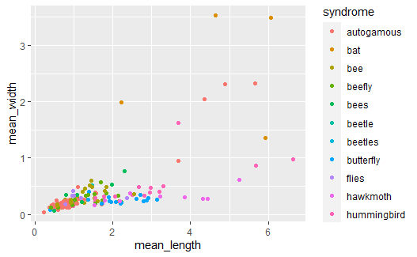

```r
phlox %>%
  ggplot(mapping=aes(x=mean_length,y=mean_width,color=syndrome))+
  geom_point()
```

```r
phlox <- phlox %>%
  mutate(species = str_replace_all(syndrome, c("bees"="bee","beetles"="beetle")))
```

#### Part 4